# Exploration Of Prosper Loan Data

## Preliminary Wrangling

> A Prosper Loan dataset of shape [113,937 x 81]. The 81 columns are including current loan status, loan amount, borrower rate etc. Each variable is explained in this data dictionary: https://docs.google.com/spreadsheets/d/1gDyi_L4UvIrLTEC6Wri5nbaMmkGmLQBk-Yx3z0XDEtI/edit?usp=sharing

```python
# import all packages and set plots to be embedded inline
import numpy as np
import pandas as pd
import matplotlib.pyplot as plt
import seaborn as sb

import warnings
warnings.filterwarnings('ignore')

%matplotlib inline
```

> Load in your dataset and describe its properties through the questions below. Try and motivate your exploration goals through this section.

```python
# load in the dataset into a pandas dataframe
df = pd.read_csv('prosperLoanData.csv')
```

```python
pd.set_option('display.max_columns', None)
df.head()
```

|  | ListingKey | ListingNumber | ListingCreationDate | CreditGrade | Term | LoanStatus | ClosedDate | BorrowerAPR | BorrowerRate | LenderYield | EstimatedEffectiveYield | EstimatedLoss | EstimatedReturn | ProsperRating (numeric) | ProsperRating (Alpha) | ProsperScore | ListingCategory (numeric) | BorrowerState | Occupation | EmploymentStatus | EmploymentStatusDuration | IsBorrowerHomeowner | CurrentlyInGroup | GroupKey | DateCreditPulled | CreditScoreRangeLower | CreditScoreRangeUpper | FirstRecordedCreditLine | CurrentCreditLines | … |
| --- | --- | --- | --- | --- | --- | --- | --- | --- | --- | --- | --- | --- | --- | --- | --- | --- | --- | --- | --- | --- | --- | --- | --- | --- | --- | --- | --- | --- | --- | --- |
| 0 | 1021339766868145413AB3B | 193129 | 2007-08-26 19:09:29.263000000 | C | 36 | Completed | 2009-08-14 00:00:00 | 0.16516 | 0.1580 | 0.1380 | NaN | NaN | NaN | NaN | NaN | NaN | 0 | CO | Other | Self-employed | 2.0 | True | True | NaN | 2007-08-26 18:41:46.780000000 | 640.0 | 659.0 | 2001-10-11 00:00:00 | 5.0 | … |
| 1 | 10273602499503308B223C1 | 1209647 | 2014-02-27 08:28:07.900000000 | NaN | 36 | Current | NaN | 0.12016 | 0.0920 | 0.0820 | 0.07960 | 0.0249 | 0.05470 | 6.0 | A | 7.0 | 2 | CO | Professional | Employed | 44.0 | False | False | NaN | 2014-02-27 08:28:14 | 680.0 | 699.0 | 1996-03-18 00:00:00 | 14.0 | … |
| 2 | 0EE9337825851032864889A | 81716 | 2007-01-05 15:00:47.090000000 | HR | 36 | Completed | 2009-12-17 00:00:00 | 0.28269 | 0.2750 | 0.2400 | NaN | NaN | NaN | NaN | NaN | NaN | 0 | GA | Other | Not available | NaN | False | True | 783C3371218786870A73D20 | 2007-01-02 14:09:10.060000000 | 480.0 | 499.0 | 2002-07-27 00:00:00 | NaN | … |
| 3 | 0EF5356002482715299901A | 658116 | 2012-10-22 11:02:35.010000000 | NaN | 36 | Current | NaN | 0.12528 | 0.0974 | 0.0874 | 0.08490 | 0.0249 | 0.06000 | 6.0 | A | 9.0 | 16 | GA | Skilled Labor | Employed | 113.0 | True | False | NaN | 2012-10-22 11:02:32 | 800.0 | 819.0 | 1983-02-28 00:00:00 | 5.0 | … |
| 4 | 0F023589499656230C5E3E2 | 909464 | 2013-09-14 18:38:39.097000000 | NaN | 36 | Current | NaN | 0.24614 | 0.2085 | 0.1985 | 0.18316 | 0.0925 | 0.09066 | 3.0 | D | 4.0 | 2 | MN | Executive | Employed | 44.0 | True | False | NaN | 2013-09-14 18:38:44 | 680.0 | 699.0 | 2004-02-20 00:00:00 | 19.0 | … |

```python
df.shape
```

```
(113937, 81)
```

```python
df.info()
```

```
<class 'pandas.core.frame.DataFrame'>
RangeIndex: 113937 entries, 0 to 113936
Data columns (total 81 columns):
 #   Column                               Non-Null Count   Dtype
---  ------                               --------------   -----
 0   ListingKey                           113937 non-null  object
 1   ListingNumber                        113937 non-null  int64
 2   ListingCreationDate                  113937 non-null  object
 3   CreditGrade                          28953 non-null   object
 4   Term                                 113937 non-null  int64
 5   LoanStatus                           113937 non-null  object
 6   ClosedDate                           55089 non-null   object
 7   BorrowerAPR                          113912 non-null  float64
 8   BorrowerRate                         113937 non-null  float64
 9   LenderYield                          113937 non-null  float64
```

[output cut: 73 more lines]

```python
#Drop the duplicates if any
df=df.drop_duplicates()
```

```python
df.shape
```

```
(113937, 81)
```

#### Let's find out the percentage of NaNs in each column

```python
each_col_missing = df.isna().sum()
```

```python
each_col_missing = each_col_missing[each_col_missing > 0]
```

```python
per100 = each_col_missing*100/df.shape[0]
```

```python
per100 = per100.round(2)
```

```python
per100.sort_values(ascending=False).head()
```

```
GroupKey                         88.29
LoanFirstDefaultedCycleNumber    85.12
ScorexChangeAtTimeOfListing      83.39
ProsperPrincipalOutstanding      80.62
ProsperPrincipalBorrowed         80.62
dtype: float64
```

```python
pd.concat([each_col_missing, per100], axis=1,
          keys=['Missing Values', 'Percentage']).\
          sort_values(by="Missing Values", ascending=False)
```

|  | Missing Values | Percentage |
| --- | --- | --- |
| GroupKey | 100596 | 88.29 |
| LoanFirstDefaultedCycleNumber | 96985 | 85.12 |
| ScorexChangeAtTimeOfListing | 95009 | 83.39 |
| ProsperPrincipalOutstanding | 91852 | 80.62 |
| ProsperPrincipalBorrowed | 91852 | 80.62 |
| ProsperPaymentsOneMonthPlusLate | 91852 | 80.62 |
| ProsperPaymentsLessThanOneMonthLate | 91852 | 80.62 |
| OnTimeProsperPayments | 91852 | 80.62 |
| TotalProsperPaymentsBilled | 91852 | 80.62 |
| TotalProsperLoans | 91852 | 80.62 |
| CreditGrade | 84984 | 74.59 |
| ClosedDate | 58848 | 51.65 |
| EstimatedEffectiveYield | 29084 | 25.53 |
| EstimatedLoss | 29084 | 25.53 |
| EstimatedReturn | 29084 | 25.53 |
| ProsperRating (numeric) | 29084 | 25.53 |
| ProsperRating (Alpha) | 29084 | 25.53 |
| ProsperScore | 29084 | 25.53 |
| DebtToIncomeRatio | 8554 | 7.51 |
| EmploymentStatusDuration | 7625 | 6.69 |
| AmountDelinquent | 7622 | 6.69 |
| BankcardUtilization | 7604 | 6.67 |
| PublicRecordsLast12Months | 7604 | 6.67 |
| RevolvingCreditBalance | 7604 | 6.67 |
| OpenCreditLines | 7604 | 6.67 |
| CurrentCreditLines | 7604 | 6.67 |
| TradesOpenedLast6Months | 7544 | 6.62 |
| AvailableBankcardCredit | 7544 | 6.62 |
| TotalTrades | 7544 | 6.62 |
| TradesNeverDelinquent (percentage) | 7544 | 6.62 |
| BorrowerState | 5515 | 4.84 |
| Occupation | 3588 | 3.15 |
| EmploymentStatus | 2255 | 1.98 |
| TotalInquiries | 1159 | 1.02 |
| DelinquenciesLast7Years | 990 | 0.87 |
| PublicRecordsLast10Years | 697 | 0.61 |
| CurrentDelinquencies | 697 | 0.61 |
| InquiriesLast6Months | 697 | 0.61 |
| TotalCreditLinespast7years | 697 | 0.61 |
| FirstRecordedCreditLine | 697 | 0.61 |
| CreditScoreRangeUpper | 591 | 0.52 |
| CreditScoreRangeLower | 591 | 0.52 |
| BorrowerAPR | 25 | 0.02 |

```python
_.index
```

```
Index(['GroupKey', 'LoanFirstDefaultedCycleNumber',
       'ScorexChangeAtTimeOfListing', 'ProsperPrincipalOutstanding',
       'ProsperPrincipalBorrowed', 'ProsperPaymentsOneMonthPlusLate',
       'ProsperPaymentsLessThanOneMonthLate', 'OnTimeProsperPayments',
       'TotalProsperPaymentsBilled', 'TotalProsperLoans', 'CreditGrade',
       'ClosedDate', 'EstimatedEffectiveYield', 'EstimatedLoss',
       'EstimatedReturn', 'ProsperRating (numeric)', 'ProsperRating (Alpha)',
       'ProsperScore', 'DebtToIncomeRatio', 'EmploymentStatusDuration',
       'AmountDelinquent', 'BankcardUtilization', 'PublicRecordsLast12Months',
       'RevolvingCreditBalance', 'OpenCreditLines', 'CurrentCreditLines',
       'TradesOpenedLast6Months', 'AvailableBankcardCredit', 'TotalTrades',
       'TradesNeverDelinquent (percentage)', 'BorrowerState', 'Occupation',
       'EmploymentStatus', 'TotalInquiries', 'DelinquenciesLast7Years',
       'PublicRecordsLast10Years', 'CurrentDelinquencies',
       'InquiriesLast6Months', 'TotalCreditLinespast7years',
       'FirstRecordedCreditLine', 'CreditScoreRangeUpper',
       'CreditScoreRangeLower', 'BorrowerAPR'],
      dtype='object')
```

> Many nulls can be witnessed (Specially in 'GroupKey', 'LoanFirstDefaultedCycleNumber', 'ScorexChangeAtTimeOfListing', 'ProsperPrincipalOutstanding', 'ProsperPrincipalBorrowed', 'ProsperPaymentsOneMonthPlusLate', 'ProsperPaymentsLessThanOneMonthLate', 'OnTimeProsperPayments', 'TotalProsperPaymentsBilled', 'TotalProsperLoans', 'CreditGrade', 'ClosedDate', 'EstimatedEffectiveYield', 'EstimatedLoss', 'EstimatedReturn', 'ProsperRating (numeric)', 'ProsperRating (Alpha)', 'ProsperScore').

> In the following section we will provide the extracted data or (region of interest)

```python
#Features
features =  [
    'Term', 'LoanStatus', 'BorrowerRate', 'ProsperRating (Alpha)', 'ListingCategory (numeric)', 'EmploymentStatus',
    'DelinquenciesLast7Years', 'StatedMonthlyIncome', 'TotalProsperLoans', 'LoanOriginalAmount',
    'LoanOriginationDate', 'Recommendations', 'Investors'
]
```

##### From the dictionary [https://docs.google.com/spreadsheets/d/1gDyi_L4UvIrLTEC6Wri5nbaMmkGmLQBk-Yx3z0XDEtI/edit#gid=0]

.Term : The length of the loan expressed in months.

.LoanStatus : The current status of the loan: Cancelled, Chargedoff, Completed, Current, Defaulted, FinalPaymentInProgress, PastDue. The PastDue status will be accompanied by a delinquency bucket.

.ProsperRating (Alpha) : The Prosper Rating assigned at the time the listing was created between AA - HR. Applicable for loans originated after July 2009.

.ListingCategory : The category of the listing that the borrower selected when posting their listing: 0 - Not Available, 1 - Debt Consolidation, 2 - Home Improvement, 3 - Business, 4 - Personal Loan, 5 - Student Use, 6 - Auto, 7- Other, 8 - Baby&Adoption, 9 - Boat, 10 - Cosmetic Procedure, 11 - Engagement Ring, 12 - Green Loans, 13 - Household Expenses, 14 - Large Purchases, 15 - Medical/Dental, 16 - Motorcycle, 17 - RV, 18 - Taxes, 19 - Vacation, 20 - Wedding Loans.

.EmploymentStatus : The employment status of the borrower at the time they posted the listing.

.DelinquenciesLast7Years : Number of delinquencies in the past 7 years at the time the credit profile was pulled.

.StatedMonthlyIncome : The monthly income the borrower stated at the time the listing was created.

.TotalProsperLoans : Number of Prosper loans the borrower at the time they created this listing. This value will be null if the borrower had no prior loans.

.LoanOriginalAmount : The origination amount of the loan.

.LoanOriginationDate : The date the loan was originated.

.Recommendations : Number of recommendations the borrower had at the time the listing was created.

.Investors : The number of investors that funded the loan.

```python
sub_df = df[features]
```

```python
sub_df.isna().sum().sort_values(ascending=False)
```

```
TotalProsperLoans            91852
ProsperRating (Alpha)        29084
EmploymentStatus              2255
DelinquenciesLast7Years        990
Investors                        0
Recommendations                  0
LoanOriginationDate              0
LoanOriginalAmount               0
StatedMonthlyIncome              0
ListingCategory (numeric)        0
BorrowerRate                     0
LoanStatus                       0
Term                             0
dtype: int64
```

From [Prosper Loan Dictionary](https://docs.google.com/spreadsheets/d/1gDyi_L4UvIrLTEC6Wri5nbaMmkGmLQBk-Yx3z0XDEtI/edit#gid=0) We get that if no previous credit history on Prosper, the value for `TotalProsperLoans` will be NaN. So it is to be put into consideration that NaN will represent 0.

```python
sub_df['TotalProsperLoans'] = sub_df['TotalProsperLoans'].fillna(0)
```

ProsperRating (Alpha):"The Prosper Rating assigned at the time the listing was created between AA - HR. Applicable for loans originated after July 2009." This is why we drop the missing values

```python
sub_df = sub_df.dropna(subset=['ProsperRating (Alpha)']).reset_index()
```

`LoanOriginationDate` to datetime

```python
sub_df['LoanOriginationDate'] = pd.to_datetime(sub_df['LoanOriginationDate'])
```

##### Using the following line to make sure the data is clean

```python
assert sub_df.notna().sum().any()
```

```python
sub_df.head(1)
```

|  | index | Term | LoanStatus | BorrowerRate | ProsperRating (Alpha) | ListingCategory (numeric) | EmploymentStatus | DelinquenciesLast7Years | StatedMonthlyIncome | TotalProsperLoans | LoanOriginalAmount | LoanOriginationDate | Recommendations | Investors |
| --- | --- | --- | --- | --- | --- | --- | --- | --- | --- | --- | --- | --- | --- | --- |
| 0 | 1 | 36 | Current | 0.092 | A | 2 | Employed | 0.0 | 6125.0 | 0.0 | 10000 | 2014-03-03 | 0 | 1 |

##### Now it's time to 'statistically summarize' using describe()

```python
statstistx=sub_df.describe().drop('index',axis=1)
```

```python
statstistx.transpose()
```

|  | count | mean | std | min | 25% | 50% | 75% | max |
| --- | --- | --- | --- | --- | --- | --- | --- | --- |
| Term | 84853.0 | 42.486135 | 11.640346 | 12.00 | 36.0000 | 36.0000 | 60.000000 | 6.000000e+01 |
| BorrowerRate | 84853.0 | 0.196022 | 0.074631 | 0.04 | 0.1359 | 0.1875 | 0.257400 | 3.600000e-01 |
| ListingCategory (numeric) | 84853.0 | 3.312647 | 4.364277 | 0.00 | 1.0000 | 1.0000 | 3.000000 | 2.000000e+01 |
| DelinquenciesLast7Years | 84853.0 | 3.659435 | 9.347957 | 0.00 | 0.0000 | 0.0000 | 2.000000 | 9.900000e+01 |
| StatedMonthlyIncome | 84853.0 | 5931.174803 | 8239.943740 | 0.00 | 3434.0000 | 5000.0000 | 7083.333333 | 1.750003e+06 |
| TotalProsperLoans | 84853.0 | 0.340789 | 0.726235 | 0.00 | 0.0000 | 0.0000 | 0.000000 | 8.000000e+00 |
| LoanOriginalAmount | 84853.0 | 9083.440515 | 6287.860058 | 1000.00 | 4000.0000 | 7500.0000 | 13500.000000 | 3.500000e+04 |
| Recommendations | 84853.0 | 0.017560 | 0.187963 | 0.00 | 0.0000 | 0.0000 | 0.000000 | 1.900000e+01 |
| Investors | 84853.0 | 68.264669 | 95.195831 | 1.00 | 1.0000 | 32.0000 | 97.000000 | 1.189000e+03 |

##### Summary for categorical columns

```python
# LoanStatus, ProsperRating (Alpha) and EmploymentStatus
sub_df.describe(include=[np.object]).transpose().drop("count", axis=1)
```

|  | unique | top | freq |
| --- | --- | --- | --- |
| LoanStatus | 11 | Current | 56576 |
| ProsperRating (Alpha) | 7 | C | 18345 |
| EmploymentStatus | 7 | Employed | 67310 |

```python
sub_df.shape
```

```
(84853, 14)
```

```python
sub_df.drop(inplace=True,columns='index')
```

```python
sub_df.shape
```

```
(84853, 13)
```

### What is the structure of your dataset?

After the cleaning phase we get a dataset of (84853, 13). These 13 columns (regions) of interest as mentioned earlier are:\ **`Term`,`LoanStatus`, `BorrowerRate`, `ProsperRating (Alpha)`, `ListingCategory (numeric)`, `EmploymentStatus`, `DelinquenciesLast7Years`, `StatedMonthlyIncome`, `TotalProsperLoans`, `LoanOriginalAmount`, `LoanOriginationDate`, `Recommendations`, `Investors`**.

All of the variables are quantitative except:

- LoanStatus
- ProsperRating (Aplha)
- EmploymentStatus
- ListingCategory (numeric)
- LoanOriginationDate

### What is/are the main feature(s) of interest in your dataset?

The question proposed in the investigation here is, "Which features to predict default on credit ?" a.k.a Correlations of the variables with prosper credit rating.

### What features in the dataset do you think will help support your investigation into your feature(s) of interest?

The borrowers Prosper rating may dramatically affect the chances of default besides the loan amount. In addition, to the Prosper rating, which is dependant on the employment status and stated income.

> Let's setup a color that matches the charts in order to not waste ink or more colors for few informations

```python
uni_color = sb.color_palette()[0]
```

> Investigation of the first variable ['Term']

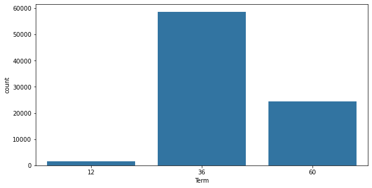

```python
plt.figure(figsize=[10,5])
sb.countplot(data = sub_df, x = 'Term', color = uni_color);
```

> > As it can be seen from the previous chart that the 36 months loan is the most common

> Investigation of the 2nd variable ['LoanStatus']

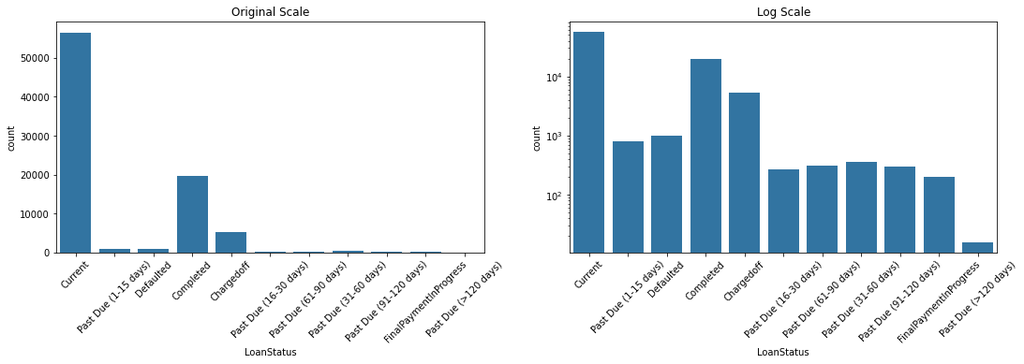

```python
plt.figure(figsize=[18,10])
plt.subplot(2,2,1)
plt.xticks(rotation=45)
sb.countplot(data = sub_df, x = 'LoanStatus', color = uni_color);
plt.title('Original Scale')
#With Log Scale
plt.subplot(2,2,2)
plt.xticks(rotation=45)
sb.countplot(data = sub_df, x = 'LoanStatus', color = uni_color);
plt.yscale('log')
plt.title('Log Scale')
```

> > I decided to use the log scale on y axis in order to see the difference of the least frequent clearly. Most of the loans are **[Current,Completed,Charedoff]** loans respectively.

> Investigation of the 3rd variable 'BorrowerRate':

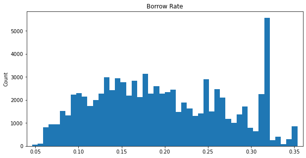

```python
plt.figure(figsize=[10,5])
plt.hist(data=sub_df, x='BorrowerRate', bins=50, color = uni_color);
plt.xlim(0.04,0.36)
plt.title('Borrow Rate')
plt.ylabel('Count')
```

> > It is a **bimodal distribution** with peak spikes. Visually, the first one is around 0.17 and the largest peak is around 0.32. But actually it is at 0.3199 and 0.3177. Hence we need to increase the number of bins to see that.

```python
sub_df.BorrowerRate.value_counts().nlargest(2)
```

```
0.3177    3672
0.3199    1645
Name: BorrowerRate, dtype: int64
```

> Investigation of the 4th variable ['ProsperRating (Alpha)'] (Categorical Ordinal Variable)

```python
sub_df['ProsperRating (Alpha)'].unique()
#From highest to lowest
order=['AA', 'A', 'B', 'C', 'D', 'E', 'HR']
order = pd.api.types.CategoricalDtype(ordered = True,
                                                categories = order)
```

```python
sub_df['ProsperRating (Alpha)']=sub_df['ProsperRating (Alpha)'].astype(order)
```

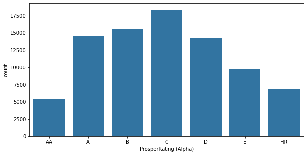

```python
plt.figure(figsize=[10,5])
sb.countplot(data=sub_df, x='ProsperRating (Alpha)', color=uni_color);
```

> > Is is a clear **normal distribution**. Where the average rating C is the most common. And the 2 edges (AA , HR) are the least frequent

> Investigation of the 5th variable ['ListingCategory (numeric)'] (Categorical Variable)

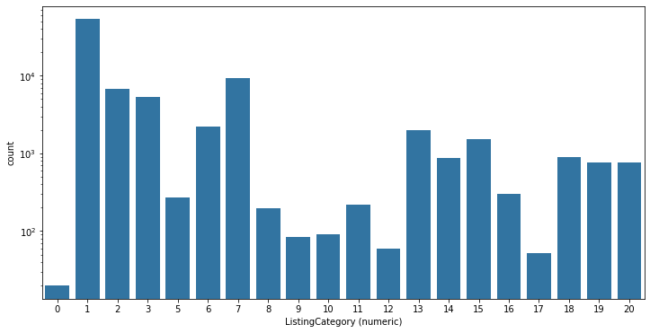

```python
plt.figure(figsize=[12,6])
sb.countplot(data=sub_df, x='ListingCategory (numeric)', color=uni_color);
plt.yscale('log')
```

> > The categories of the variable are : 0 - Not Available, 1 - Debt Consolidation, 2 - Home Improvement, 3 - Business, 4 - Personal Loan, 5 - Student Use, 6 - Auto, 7- Other, 8 - Baby&Adoption, 9 - Boat, 10 - Cosmetic Procedure, 11 - Engagement Ring, 12 - Green Loans, 13 - Household Expenses, 14 - Large Purchases, 15 - Medical/Dental, 16 - Motorcycle, 17 - RV, 18 - Taxes, 19 - Vacation, 20 - Wedding Loans. \ **The majority of the loans are used for debt consolidation, Other, Home Improvement, Business and Auto respectively.**

> Investigation of the 6th variable ['EmploymentStatus'] (Categorical Variable)

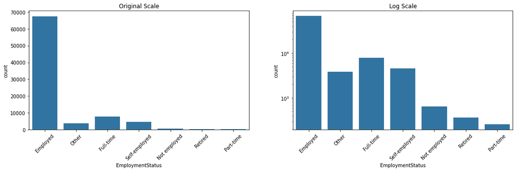

```python
plt.figure(figsize=[18,10])
plt.subplot(2,2,1)
sb.countplot(data=sub_df, x='EmploymentStatus', color=uni_color)
plt.xticks(rotation=45)
plt.title('Original Scale');
plt.subplot(2,2,2)
sb.countplot(data=sub_df, x='EmploymentStatus', color=uni_color)
plt.yscale('log')
plt.xticks(rotation=45)
plt.title('Log Scale');
```

> > Also I decided to use the log scale to clearly see the difference between each status. As it can be witnessed that the employed status is the most frequent and specially the Full-Time employment then the self-employment and other respectively

> Investigation of 7th variable 'DelinquenciesLast7Years'

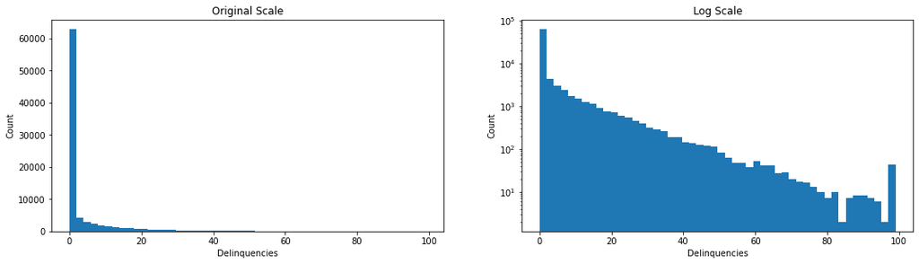

```python
plt.figure(figsize=[18,10])
plt.subplot(2,2,1)
plt.hist(data=sub_df, x='DelinquenciesLast7Years', bins=50, color=uni_color);
plt.ylabel('Count')
plt.xlabel('Delinquencies');
plt.title('Original Scale')
plt.subplot(2,2,2)
plt.hist(data=sub_df, x='DelinquenciesLast7Years', bins=50, color=uni_color);
plt.ylabel('Count')
plt.yscale('log')
plt.title('Log Scale')
plt.xlabel('Delinquencies');
```

> > Majority of the Prosper clients are **0 delinquencies for the last 7 years**, a small minority has up to 20 delinquencies and very less had more than 20. On the log scale, some additional informations are to be witnessed such as the 100 delinquencies

> Investigation of 8th variable 'StatedMonthlyIncome'

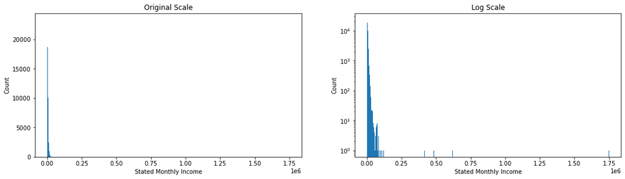

```python
plt.figure(figsize=[18,10])
plt.subplot(2,2,1)
plt.hist(data=sub_df, x='StatedMonthlyIncome', bins=1000, color=uni_color);
plt.ylabel('Count')
plt.xlabel('Stated Monthly Income');
plt.title('Original Scale')
plt.subplot(2,2,2)
plt.hist(data=sub_df, x='StatedMonthlyIncome', bins=1000, color=uni_color);
plt.ylabel('Count')
plt.yscale('log')
plt.title('Log Scale')
plt.xlabel('Stated Monthly Income');
```

The distribution of higly right skewed. We'll remove the outliers in the next section

```python
income_std = sub_df['StatedMonthlyIncome'].std()
income_mean = sub_df['StatedMonthlyIncome'].mean()
boundary = income_mean + income_std * 3
len(sub_df[sub_df['StatedMonthlyIncome'] >= boundary])
```

```
245
```

> > Another Look For The Previous Plot But This Time With Boundary

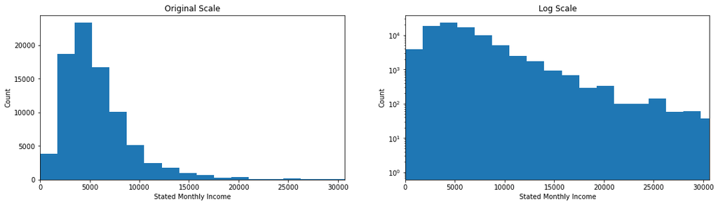

```python
plt.figure(figsize=[18,10])
plt.subplot(2,2,1)
plt.hist(data=sub_df, x='StatedMonthlyIncome', bins=1000, color=uni_color);
plt.ylabel('Count')
plt.xlabel('Stated Monthly Income');
plt.title('Original Scale')
plt.xlim(0,boundary)
plt.subplot(2,2,2)
plt.hist(data=sub_df, x='StatedMonthlyIncome', bins=1000, color=uni_color);
plt.ylabel('Count')
plt.yscale('log')
plt.title('Log Scale')
plt.xlabel('Stated Monthly Income')
plt.xlim(0,boundary);
```

> > With a fair distribution with boundary of mean and three standard deviations. Its distribution still is right skew and we can mention that the mode is 5,000.

> Investigation of 9th variable 'TotalProsperLoans'

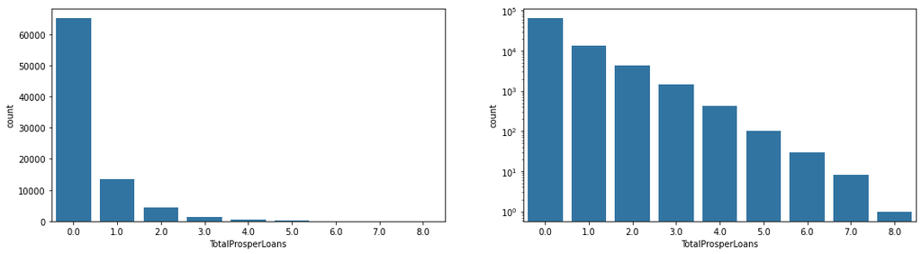

```python
plt.figure(figsize=[18,10])
plt.subplot(2,2,1)
sb.countplot(data=sub_df, x='TotalProsperLoans', color=uni_color);
plt.subplot(2,2,2)
sb.countplot(data=sub_df, x='TotalProsperLoans', color=uni_color)
plt.yscale('log')
```

> > Most clients, this is their 1st loan at prosper, small minority of clients already borrowed [1, 2, 3] loans respectiely. And few have maximum loans of 8

> Investigation of 10th variable 'LoanOriginalAmount'

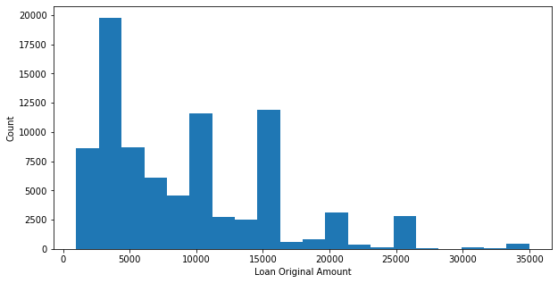

```python
plt.figure(figsize=[10,5])
plt.hist(data=sub_df, x='LoanOriginalAmount', bins=20, color=uni_color)
plt.ylabel('Count')
plt.xlabel('Loan Original Amount');
```

> > As it can be witnessed the spikes shows that most of the people borrow with 5000,10000,150000 etc. By the increment of 5000.

> Investigation of 11th variable 'LoanOriginationDate' (Datetime Type)

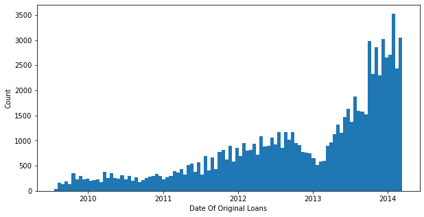

```python
plt.figure(figsize=[10,5])
plt.hist(data=sub_df, x='LoanOriginationDate', bins=100, color=uni_color)
plt.ylabel('Count')
plt.xlabel('Date Of Original Loans');
```

```python
sub_df['LoanOriginationDate'].describe()
```

```
count                   84853
unique                   1165
top       2014-01-22 00:00:00
freq                      491
first     2009-07-20 00:00:00
last      2014-03-12 00:00:00
Name: LoanOriginationDate, dtype: object
```

> Investigation of 12th variable 'Recommendations'

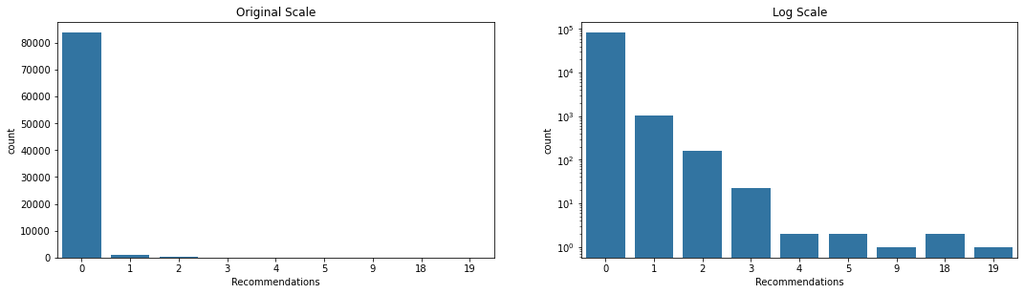

```python
plt.figure(figsize=[18,10])
plt.subplot(2,2,1)
sb.countplot(data=sub_df, x='Recommendations', color=uni_color)
plt.title('Original Scale');
plt.subplot(2,2,2)
sb.countplot(data=sub_df, x='Recommendations', color=uni_color)
plt.yscale('log')
plt.title('Log Scale');
```

> > Most of the loans came from no recommendations

> Investigation of 13th variable 'Investors'

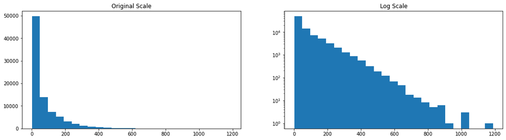

```python
plt.figure(figsize=[18,10])
plt.subplot(2,2,1)
plt.hist(data=sub_df, x='Investors', bins=25, color=uni_color)
plt.title('Original Scale');
plt.subplot(2,2,2)
plt.hist(data=sub_df, x='Investors', bins=25, color=uni_color)
plt.yscale('log')
plt.title('Log Scale');
```

> > Most common loans have only one investor and the 2nd most common loans are the range in between 1 to less than 300 investors but few have about 1200 investors.

### Discuss the distribution(s) of your variable(s) of interest. Were there any unusual points? Did you need to perform any transformations?

> Prosper ratings are almost normally distributed. Distribution of monthly stated income is very awkward: with a lot of outliers and a very large range of values, because this is evidently based on borrowers' self-reporting, I think there is a lot of wrong values, we will wrangle with it bellow. I did not feel like any scale transformations can be useful here. Most loans are below 15,000, it seems like most loans are increments of 5,000.

### Of the features you investigated, were there any unusual distributions? Did you perform any operations on the data to tidy, adjust, or change the form of the data? If so, why did you do this?

> There are some issues that will be adjusted on the next section for some variables such as: ListingCategory (numeric), LoanStatus and StatedMonthlyIncome. No there wasn't any tidiness issue or combination issue.

> Our main goal is to define driving factors of outcome of loan. Hence, we are not interested in any current loans (and loans with a specified past due period) also chargedoff loans are to be considered as defaulted. These adjustments will be done in the next section.

```python
sub_df['LoanStatus'].value_counts()
```

```
Current                   56576
Completed                 19664
Chargedoff                 5336
Defaulted                  1005
Past Due (1-15 days)        806
Past Due (31-60 days)       363
Past Due (61-90 days)       313
Past Due (91-120 days)      304
Past Due (16-30 days)       265
FinalPaymentInProgress      205
Past Due (>120 days)         16
Name: LoanStatus, dtype: int64
```

```python
area_of_interest = (sub_df['LoanStatus'] == 'Completed') | (sub_df['LoanStatus'] == 'Defaulted') | (sub_df['LoanStatus'] == 'Chargedoff')
sub_df = sub_df[area_of_interest]
```

```python
# setting chargedoff as defaulted
def change_to_defaulted(row):
    if row['LoanStatus'] == 'Chargedoff':
        return 'Defaulted'
    else:
        return row['LoanStatus']
```

```python
sub_df['LoanStatus'] = sub_df.apply(change_to_defaulted, axis=1)
```

```python
sub_df['LoanStatus'].value_counts()
```

```
Completed    19664
Defaulted     6341
Name: LoanStatus, dtype: int64
```

> 'ListingCategory (numeric)' must be categorical and the reduction of the number of categories is needed

```python
categories = {1: 'Debt Consolidation', 2: 'Home Improvement', 3: 'Business', 6: 'Auto', 7: 'Other'}
def reduce_categories(row):
    loan_category = row['ListingCategory (numeric)']
    if  loan_category in categories:
        return categories[loan_category]
    else:
        return categories[7]
```

```python
sub_df['ListingCategory (numeric)'] = sub_df.apply(reduce_categories, axis=1)
```

```python
sub_df['ListingCategory (numeric)'].value_counts()
```

```
Debt Consolidation    12740
Other                  7083
Home Improvement       2612
Business               2366
Auto                   1204
Name: ListingCategory (numeric), dtype: int64
```

> Eliminate outliers in 'StatedMontlyIncome'

```python
income_std = sub_df['StatedMonthlyIncome'].std()
income_mean = sub_df['StatedMonthlyIncome'].mean()
boundary = income_mean + income_std * 3
len(sub_df[sub_df['StatedMonthlyIncome'] >= boundary])
```

```
103
```

```python
sub_df = sub_df[sub_df['StatedMonthlyIncome'] < boundary]
```

```python
len(sub_df[sub_df['StatedMonthlyIncome'] >= boundary])
```

```
0
```

## Bivariate Exploration

> The pair-wise correlation visualization between all variables (Numeric ones)

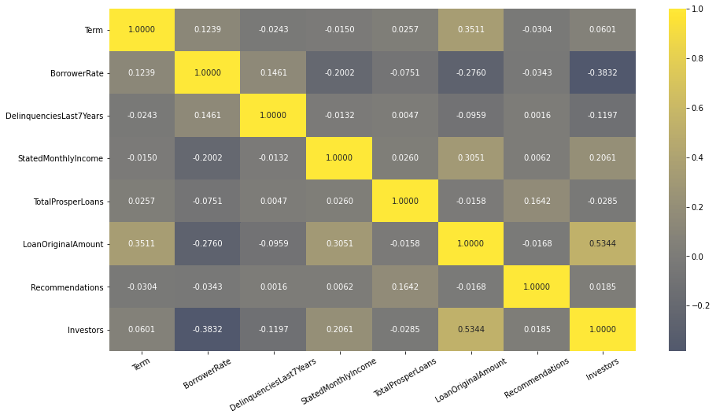

```python
num_features = ['Term', 'BorrowerRate', 'DelinquenciesLast7Years', 'StatedMonthlyIncome',
                'TotalProsperLoans', 'LoanOriginalAmount', 'Recommendations', 'Investors']

plt.figure(figsize = [15, 8])
sb.heatmap(sub_df[num_features].corr(), fmt = '.4f',cmap = 'cividis', center = 0, annot = True)
plt.xticks(rotation=30);
```

> For categorical features our numerical features will be LoanOriginalAmount & BorrowerRate in our investigation

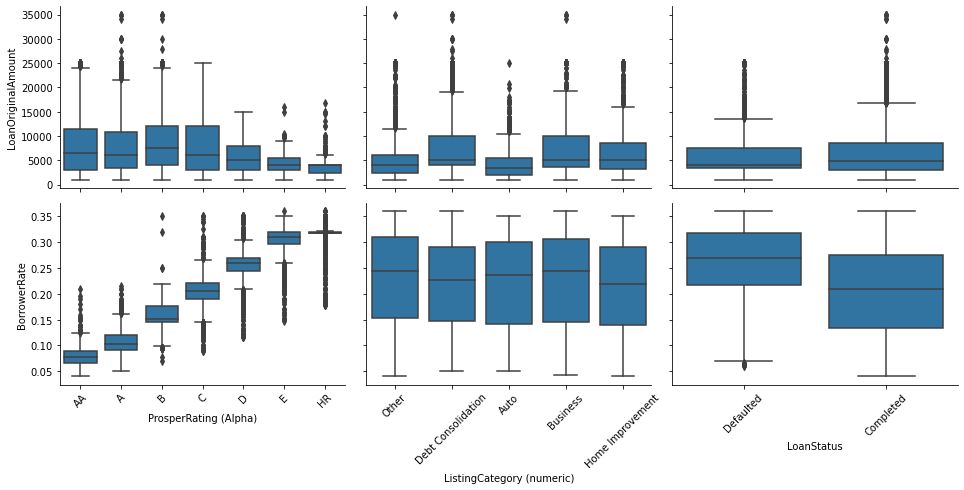

```python
num_features = ['LoanOriginalAmount', 'BorrowerRate']
cat_features = ['ProsperRating (Alpha)', 'ListingCategory (numeric)', 'LoanStatus']


def boxgrid(x, y, **kwargs):
    """ Quick hack for creating box plots with seaborn's PairGrid. """
    sb.boxplot(x, y, color = uni_color)
    plt.xticks(rotation=45)

plt.figure(figsize = [10, 10])
g = sb.PairGrid(data = sub_df, y_vars =num_features, x_vars = cat_features,
                height = 3, aspect = 1.5)
plt.xticks(rotation=45)
g.map(boxgrid);
plt.xticks(rotation=45)
plt.show();
```

> Now it's time to check what is the variable that influences an outcome of credit. At first, Listing Category & LoanStatus.

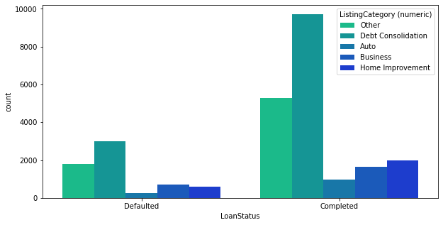

```python
plt.figure(figsize=[10,5])
sb.countplot(data=sub_df, x='LoanStatus', hue='ListingCategory (numeric)', palette='winter_r');
```

> > In each class ('Defaulted' and 'Completed'), the proportion for business and home improvement category is lower than than for other or debt consolidation category.

> 'LoanStatus and 'ProsperRating (Alpha)'

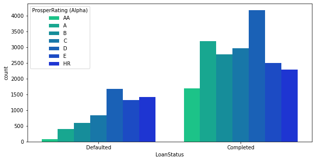

```python
plt.figure(figsize=[10,5])
sb.countplot(data=sub_df, x='LoanStatus', hue='ProsperRating (Alpha)', palette='winter_r');
```

> > The most common rating among 'Defaulted' loans is 'D', this is quite interesting the known logic is that 'HR' should be the most common rating for defaulted debts.

> 'LoanStatus' and 'Investors'

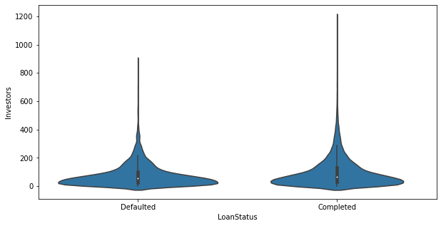

```python
#This time using Violin plot
plt.figure(figsize=[10,5])
sb.violinplot(data = sub_df, x = 'LoanStatus', y = 'Investors', color = uni_color);
```

> > 'Defaulted' credits usually have fewer investors than 'Completed'

> 'EmploymentStatus' & 'LoanStatus'

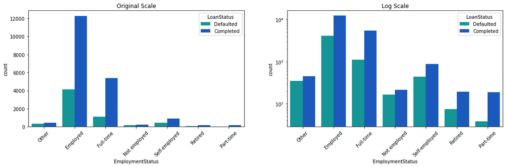

```python
plt.figure(figsize=[18,10])
plt.subplot(2,2,1)
plt.xticks(rotation=45)
sb.countplot(data=sub_df, x='EmploymentStatus', hue='LoanStatus', palette='winter_r');
plt.title('Original Scale')
plt.subplot(2,2,2)
plt.yscale('log')
plt.xticks(rotation=45)
plt.title('Log Scale')
sb.countplot(data=sub_df, x='EmploymentStatus', hue='LoanStatus', palette='winter_r');
```

> > Again using the log scale it shows the information clearly. And visually we can notice that borrowers with 'EmploymentStauts' = 'Not Employed' or 'Self-employed are more likely to get default on credit.

> 'LoanStatus' & 'LoanAmount'

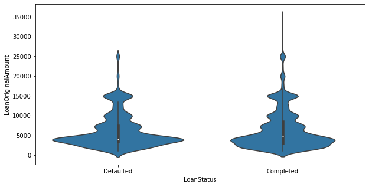

```python
plt.figure(figsize=[10,5])
sb.violinplot(data = sub_df, x = 'LoanStatus', y = 'LoanOriginalAmount', color = uni_color);
```

> > 'Defaulted' is noticed to be smaller than completed, visually.

> 'Term' & 'LoanStatus'

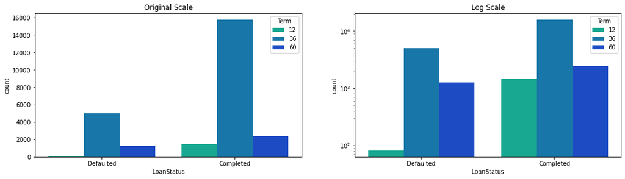

```python
plt.figure(figsize=[18,10])
plt.subplot(2,2,1)
plt.title('Original Scale')
sb.countplot(data=sub_df, x='LoanStatus', hue='Term', palette='winter_r');
plt.subplot(2,2,2)
plt.yscale('log')
plt.title('Log Scale')
sb.countplot(data=sub_df, x='LoanStatus', hue='Term', palette='winter_r');
```

> > Loans with 'Term' = 60 months on 'Defaulted' have the highest proportion.

On the next stage we will investigate the features that affect 'ProsperRating (Alpha)' of the client.

> Firstly, 'StatedMonthlyIncome' with 'ProsperRating (Alpha)'.

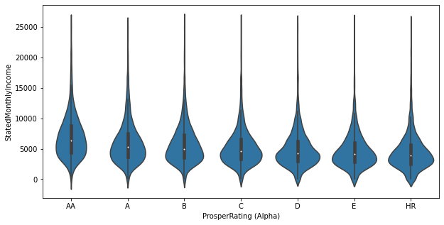

```python
plt.figure(figsize=[10,5])
sb.violinplot(data = sub_df, x = 'ProsperRating (Alpha)', y = 'StatedMonthlyIncome', color = uni_color);
```

> > So, from the correlation matrix before, we expected that the individuals with high 'StatedMonthlyIncome' are to have high 'ProsperRating (Alpha)'. This violin plot agrees.

> At second, 'Investors' with 'ProsperRating(Alpha)'

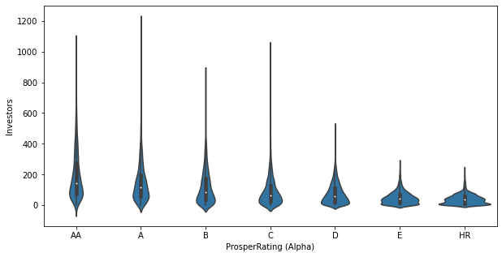

```python
plt.figure(figsize=[10,5])
sb.violinplot(data = sub_df, x='ProsperRating (Alpha)', y='Investors', color = uni_color);
```

> > Another agreement from the correlation matrix we expected, the borrowers with higher ratings on average have more investors.

> At third, 'TotalProsperLoans' with 'ProsperRating (Alpha)'

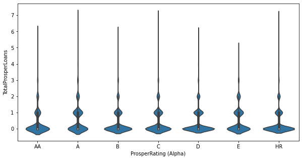

```python
plt.figure(figsize=[10,5])
sb.violinplot(data = sub_df, x = 'ProsperRating (Alpha)', y = 'TotalProsperLoans', color = uni_color);
```

> > The correlation matrix agreed with this plot that there is no relation between prosper rating and number of prosper loans.

> At fourth, 'EmploymentStatus' with 'ProsperRating (Alpha)'

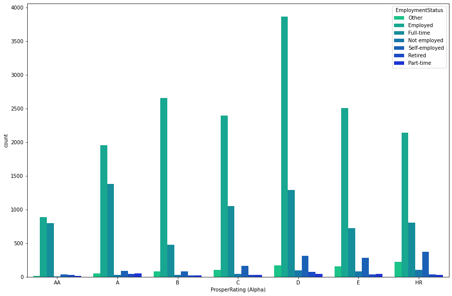

```python
plt.figure(figsize = [15, 10])
sb.countplot(data = sub_df, x = 'ProsperRating (Alpha)', hue = 'EmploymentStatus', palette='winter_r');
```

> > Lower ratings is accompanied individuals with 'EmploymentStatus' [Not Employed, Self-employed, Retired, Part-Time].

> 'DelinquenciesLast7Years' & 'ProsperRating (Alpha)'

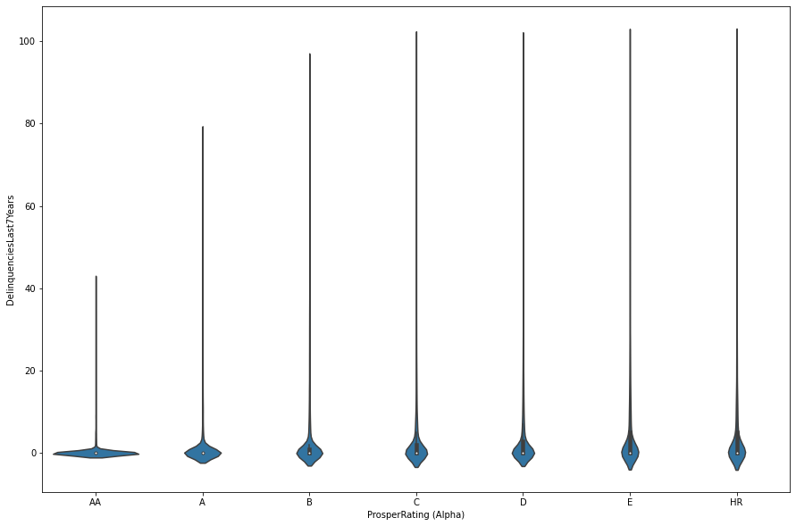

```python
plt.figure(figsize = [15, 10])
sb.violinplot(data = sub_df, x = 'ProsperRating (Alpha)', y = 'DelinquenciesLast7Years', color = uni_color);
```

> > Individuals with higher AA rating are experiencing less delinquencies than others.

### Did you observe any interesting relationships between the other features (not the main feature(s) of interest)?

> Recently, we've mentioned this observation which is as follows: Prosper rating D is the most common rating among defaulted credits which is quite interesting.

## Multivariate Exploration

> Features of interest to be explored are ['Term', 'BorrowerRate', 'DelinquenciesLast7Years', 'StatedMonthlyIncome', 'LoanOriginalAmount', 'LoanStatus']

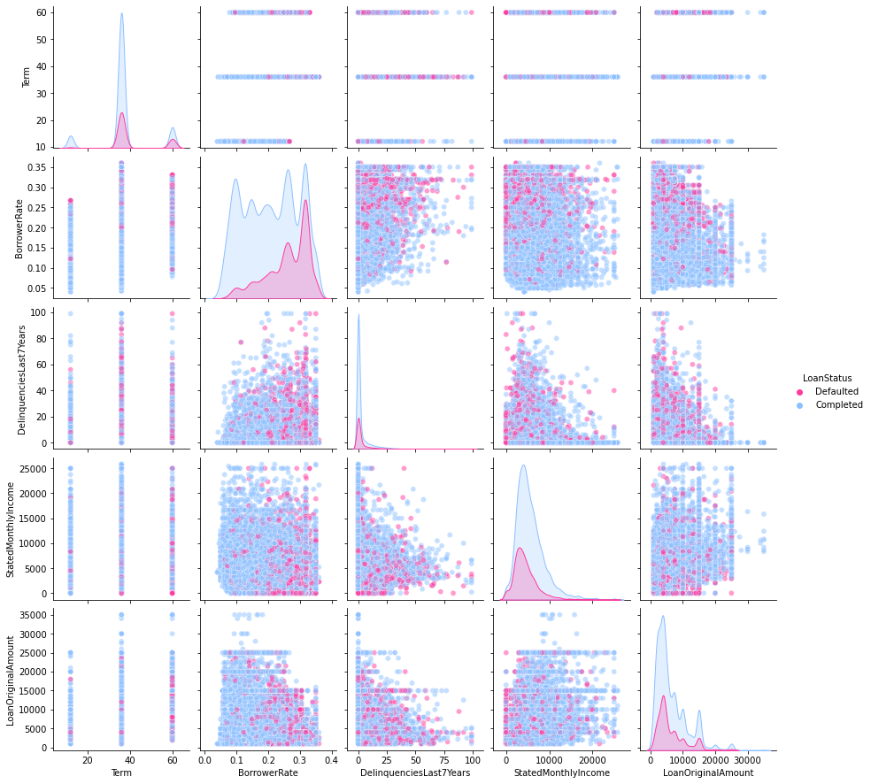

```python
cols = [
    'Term', 'BorrowerRate', 'DelinquenciesLast7Years', 'StatedMonthlyIncome',
    'LoanOriginalAmount', 'LoanStatus'
       ]
g = sb.pairplot(sub_df[cols], hue='LoanStatus',
                palette={'Defaulted': '#ff3ba0', 'Completed': '#8cc0ff'},
                plot_kws={'alpha': 0.5, 'edgecolor': 'white'})
fig = g.fig;
```

> > Both ['DelinquenciesLast7Years', 'BorrowerRate'] visually are the best predictors for an outcome of the credit.

> For categorical features, the visualization of relationships between ['ProsperRating (Alpha)', 'LoanOriginalAmount','LoanStatus'] is as follows:

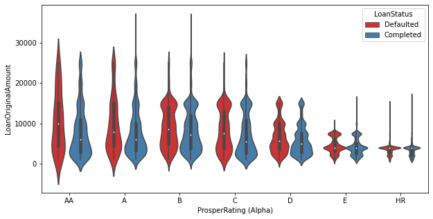

```python
plt.figure(figsize = [10, 5])
sb.violinplot(data=sub_df, x='ProsperRating (Alpha)', y='LoanOriginalAmount', hue='LoanStatus', palette="Set1");
```

> Now we investigate ['ListingCategory (numeric)','LoanOriginalAmount'] on 'LoanStatus'

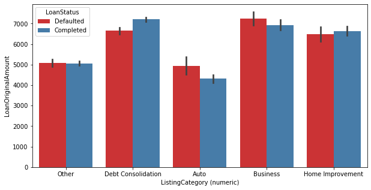

```python
plt.figure(figsize = [10, 5])
sb.barplot(data=sub_df, x='ListingCategory (numeric)', y='LoanOriginalAmount', hue='LoanStatus', palette="Set1");
```

> Now we investigate the relationships between 'ListingCategory (numeric)','ProsperRating (Alpha)' on 'LoanStatus

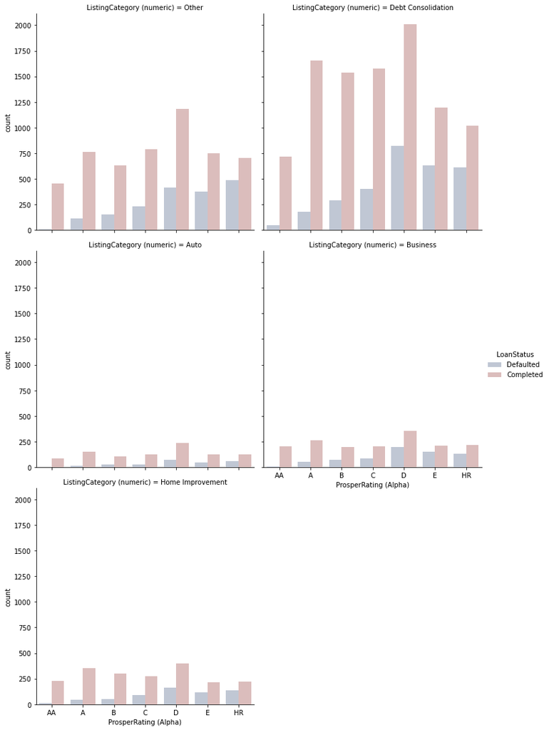

```python
plt.figure(figsize=[10,7])
sb.catplot(x='ProsperRating (Alpha)', hue='LoanStatus', col='ListingCategory (numeric)',
              data=sub_df, kind='count', palette='vlag', col_wrap=2
             );
```

> > Nothing is interesting, there is no noticeable difference for 'Defaulted' in'ListingCategory (numeric)' by 'ProsperRating (Alpha)'

> Investigation of the relation of ['Term','ListingCategory (numeric)'] on 'LoanStatus':

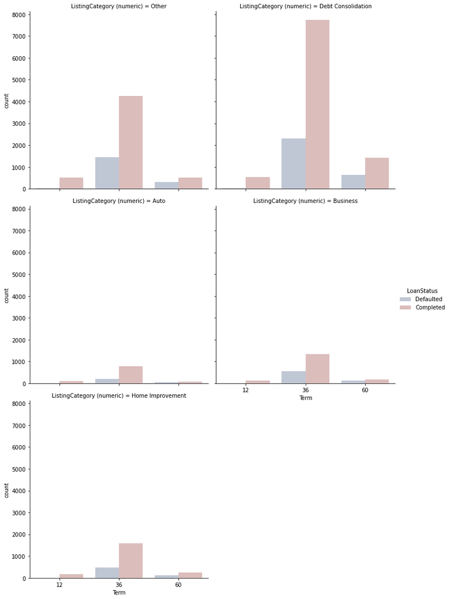

```python
sb.catplot(x='Term', hue='LoanStatus', col='ListingCategory (numeric)',
              data=sub_df, kind='count', palette='vlag', col_wrap=2
             );
```

> > As expected, it can be witnessed that long-term (60 months) credits are to be risky for the majority of the categories.

> Now we investigate 'Term', 'ProsperRating (Alpha)' on 'LoanStatus'

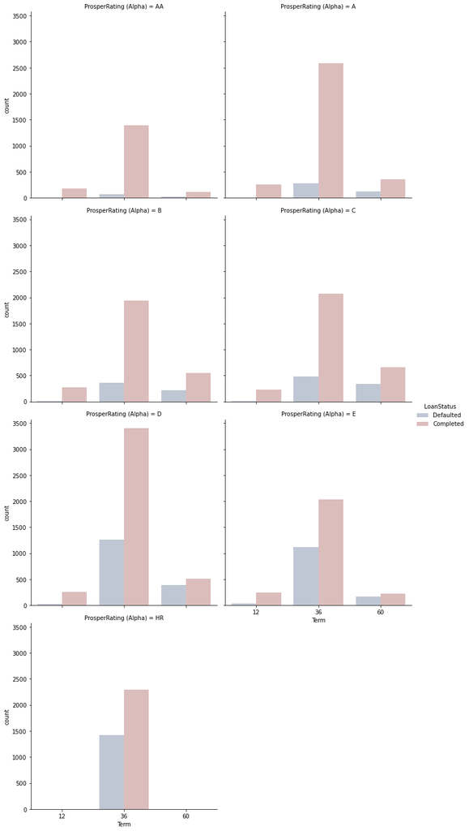

```python
sb.catplot(x='Term', hue='LoanStatus', col='ProsperRating (Alpha)',
              data=sub_df, kind='count', palette='vlag', col_wrap=2
             );
```

> > Exactly, as we mentioned in the previous section, long-term (60 months) credit are riskier than mid-term (36 months) or short-term (12 months). In addition to another observation, interestingly, the most lower credit rating has no short-term or long-term credits but only mid-term.

### Talk about some of the relationships you observed in this part of the investigation. Were there features that strengthened each other in terms of looking at your feature(s) of interest?

> The assumptions at the beginning are all being agreed such as:
> - The dependency of the outcome of credit 'LoanStatus' on ['ProsperRating (Alpha)', 'Term', 'EmploymentStatus'].
> - 'Defaulted' credits are larger than 'Completed' for most of the 'ProsperRating (Alpha)'unlike the the lowest ones.
> - Long term (60 months) loans are having much more risks than mid-term or short term.

### Were there any interesting or surprising interactions between features?

> - Interestingly, the observation of 'Defaulted' credits for individuals with high 'ProsperRating (Alpha)' tend to be larger than completed credits.
> - Another interesting observation is that individuals with the lowest rating (HR) are only having mid-term (36 months) credits.